# Assignment 05 - Solutions

Statistical Computing and Empirical Methods

Kaustubh Heamnt Sonawane (2701553)

## A word of advice

Think of the SCEM labs as going to the gym: if you pay a gym membership, but instead of working out you use a machine to lift the weights for you, you won’t get the benefits.

ChatGPT, DeepSeek, Claude and other GenAI tools can provide answers to most of the questions below. Before you try that, please consider the following: answering the specific questions below is not the point of this assignment. Instead, the questions are designed to give you the chance to develop a better understanding of estimation concepts and a certain level of **statistical thinking**. These are essential skills for any data scientist, even if they end up using generative AI - to write an effective prompt and to catch the common (often subtle) errors that AI produces when trying to solve anything non-trivial.

A very important part of this learning involves not having the answers ready-made for you, but instead taking the time to actually search for the answer, trying something, getting it wrong, and trying again.

So, make the best use of this session. The assignments are not marked, so it is much better to try the yourself even if you get incorrect answers (you’ll be able to correct yourself later when you receive feedback) than to submit a perfect, but GPT’d solution.

## IMPORTANT NOTES:

- **DO NOT** change the code block names. Enter your solutions to each question into the predefined code blocks.
- **DO NOT** add calls to `install.packages()` into your solutions. Some questions may require you to load packages using `library()`. Please do not use any other packages except the ones explicitly listed in the “setup” code block.

## Setup

### Q1: Warm up:

**a.** Read the file `fc_weight_perception.csv` into a variable called `df`.

```r
## Question 1.a

df = read.csv("fc_weight_perception.csv")

head(df)
```

```
##   Id Estimate
## 1  1       80
## 2  2       75
## 3  3      120
## 4  4       70
## 5  5       71
## 6  6       70
```

```r
dim(df)
```

```
## [1] 157   2
```

```r
summary(df)
```

```
##        Id         Estimate
##  Min.   :  1   Min.   :  0.00
##  1st Qu.: 40   1st Qu.: 70.00
##  Median : 79   Median : 74.00
##  Mean   : 79   Mean   : 74.03
##  3rd Qu.:118   3rd Qu.: 80.00
##  Max.   :157   Max.   :120.00
```

**b.** Plot the histogram of the values in column `Estimate` of the dataframe `df`.

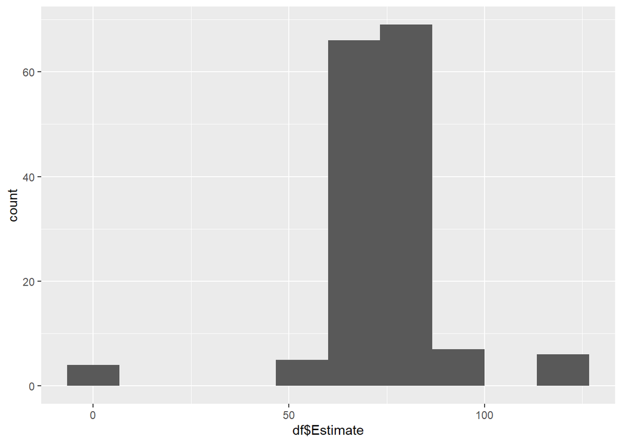

```r
## Question 1.b
ggplot(data = df, aes(x = df$Estimate)) + geom_histogram(bins = 10)
```

**c.** Remove the observations with `Estimate` < 30 or `Estimate` > 110 from the dataframe `df`. Store the filtered data as `df2`.

```r
## Question 1.c
df2 = df %>%
  filter(Estimate > 30, Estimate < 110)

dim(df2)
```

```
## [1] 147   2
```

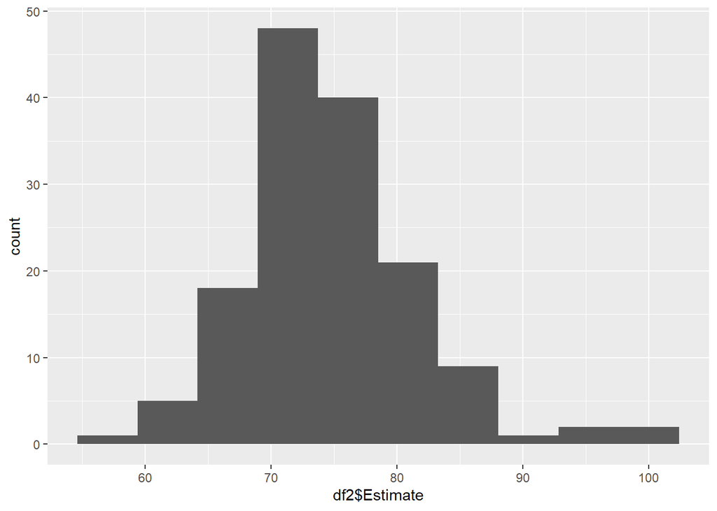

```r
ggplot(data = df2, aes(x = df2$Estimate)) + geom_histogram(bins = 10)
```

```r
summary(df2)
```

```
##        Id            Estimate
##  Min.   :  1.00   Min.   : 57.00
##  1st Qu.: 39.50   1st Qu.: 70.00
##  Median : 76.00   Median : 74.00
##  Mean   : 76.76   Mean   : 74.19
##  3rd Qu.:113.50   3rd Qu.: 78.00
##  Max.   :157.00   Max.   :100.00
```

```r
?t.test
## starting httpd help server ... done
```

### Q2: Formalising your hypotheses

**a.** Use the template below to express your null and alternative hypotheses.

```r
mytest = t.test(
  df2$Estimate,
  mu = 81,
  alternative = "two.sided",
  conf.level = 0.95
)

mytest
```

```
##
##  One Sample t-test
##
## data:  df2$Estimate
## t = -11.222, df = 146, p-value < 2.2e-16
## alternative hypothesis: true mean is not equal to 81
## 95 percent confidence interval:
##  72.98559 75.38584
## sample estimates:
## mean of x
##  74.18571
```

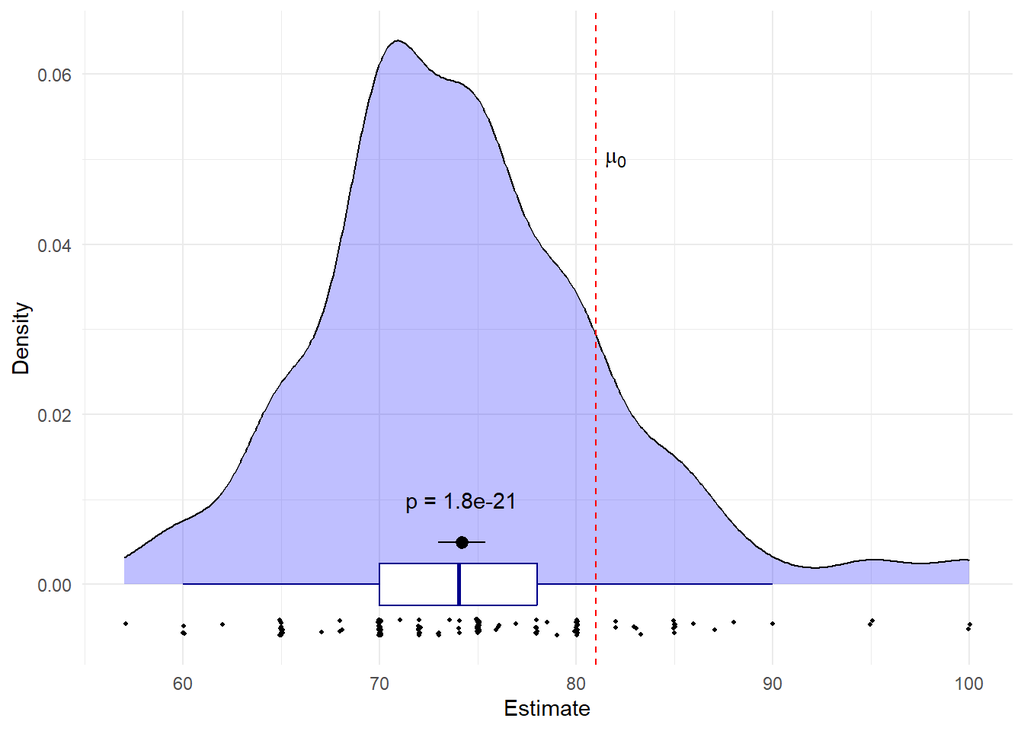

```r
ggplot(df2, aes(x = Estimate)) +
  # Density plot
  geom_density(fill = "blue", alpha = 0.25) +
  # Boxplot
  geom_boxplot(width = 0.005, outliers = FALSE, col = "darkblue") +
  # # Plot points with vertical jittering
  geom_jitter(aes(y = -0.005), height = 0.001, size = .75) +
  # # H0 value line
  geom_vline(xintercept = mytest$null.value, linetype = 2, col = "red") +
  # Add confidence interval
  annotate("pointrange", y = .005, x = mytest$estimate, xmin = mytest$conf.int[1], xmax = mytest$conf.int[2]) +
  # Add p-value
  annotate("text", x = mytest$estimate, y = 0.01, label = paste0("p = ", signif(mytest$p.value, 2))) +
  # Add text annotation
  annotate("text", x = mytest$null.value + 1, y = 0.05, label = "mu[0]", parse = TRUE) +
  theme_minimal() +
  ylab("Density")
```

### Q3: one-sided t-test

**a.** Use the function `readRDS()` to read that file into a variable called `df.comp`.

```r
## Question 3.a

df.comp = readRDS("EBV-200-HybridA-performance.rds")
df.comp
```

```
## # A tibble: 12 × 13
##    Info_organism Info_Type Info_size Info_Replicate  sens  spec   ppv   npv
##    <chr>         <chr>         <dbl>          <dbl> <dbl> <dbl> <dbl> <dbl>
##  1 EBV           HybridA         200              1 0.821 0.273 0.691 0.434
##  2 EBV           HybridA         200              2 0.877 0.216 0.689 0.469
##  3 EBV           HybridA         200              3 0.718 0.375 0.695 0.401
##  4 EBV           HybridA         200              4 0.768 0.178 0.650 0.279
##  5 EBV           HybridA         200              5 0.811 0.181 0.663 0.326
##  6 EBV           HybridA         200              6 0.766 0.330 0.694 0.416
##  7 EBV           HybridA         200              7 0.829 0.235 0.682 0.409
##  8 EBV           HybridA         200              8 0.850 0.229 0.686 0.434
##  9 EBV           HybridA         200              9 0.818 0.248 0.683 0.406
## 10 EBV           HybridA         200             10 0.837 0.127 0.655 0.282
## 11 EBV           HybridA         200             11 0.795 0.340 0.705 0.455
## 12 EBV           HybridA         200             12 0.874 0.260 0.701 0.509
## # ℹ 5 more variables: f1 <dbl>, mcc <dbl>, auc <dbl>, acc <dbl>, balacc <dbl>
```

**b.** Formalise the null and alternative hypotheses being tested in each case (complete below).

The hypotheses being tested are: $$
$$\begin{cases}
H_0: \mu_{ppv} <= 0.5\\
H_1: \mu_{ppv} > 0.5
\end{cases}$$
$$\begin{cases}
H_0: \mu_{npv} <= 0.5 \\
H_1: \mu_{npv} > 0.5
\end{cases}$$

**c.** Using the `t.test` function to test the hypotheses on the mean PPV at the $99\%$ confidence level.

```r
## Question 3.c

my_test1 = t.test(
  df.comp$ppv,
  mu = 0.5,
  alternative = "greater",
  conf.level = 0.99
)

my_test1
```

```
##
##  One Sample t-test
##
## data:  df.comp$ppv
## t = 35.596, df = 11, p-value = 5.17e-13
## alternative hypothesis: true mean is greater than 0.5
## 99 percent confidence interval:
##  0.6689597       Inf
## sample estimates:
## mean of x
## 0.6829278
```

```r
## Don't forget to store the result of the t-test as variable mytest.ppv
```

**d.** Repeat the same test (with the same confidence level) for the mean NPV, and store the result of your test in a variable called `mytest.npv`. Inspect the result of this test too - is it statistically significant, what are the sample mean $\bar{X}$ and the $99\%$ confidence interval?

```r
## Question 3.d

my_test2 = t.test(
  df.comp$npv,
  mu = 0.5,
  alternative = "greater",
  conf.level = 0.99
)

my_test2
```

```
##
##  One Sample t-test
##
## data:  df.comp$npv
## t = -4.7449, df = 11, p-value = 0.9997
## alternative hypothesis: true mean is greater than 0.5
## 99 percent confidence interval:
##  0.3453563       Inf
## sample estimates:
## mean of x
## 0.4016785
```

```r
## Don't forget to store the result of the t-test as variable mytest.npv
```

P-value for PPV is 5.17e-13 which is significantly lower that 0.01 and true mean 0.683 is also greater than 0.5 thus null hypothesis rejected.

P-value for NPV is 0.9997 which is significantly higher that 0.01 and true mean 0.402 is also lower than 0.5 thus null hypothesis is accepted.

**e.** Based on the result of your tests and on the definition of what makes a useful test provided at the start of this question, can we consider the baseline model tested as a useful method?

Sine the null hypothesis was not rejected for NPV even though it was rejected for PPV the baseline model is not better.

### Q4: power and sample size

**a.** Compute the sample size required for 90% power at $\alpha = 0.05$. Store it (just the sample size, not the entire output of `power.t.test()`) as variable `myN`.

```r
## Question 4.a

## Don't forget to store the sample size as variable myN.
## Remember that sample sizes should be integers.

?power.t.test()

myN = power.t.test(
  delta = 0.01,
  sd = 0.05,
  power = 0.9,
  sig.level = 0.05,
  type = "two.sample",  # Not sure as to what should be here? two since it is an improvement being tested?
  alternative = "one.sided",
)$n

myN
```

```
## [1] 428.8705
```

**b.** Build a *power curve* and store it as dataframe `power.df` with columns `n` and `power`. Then then use ggplot2 to plot the `n` versus `power` curve.

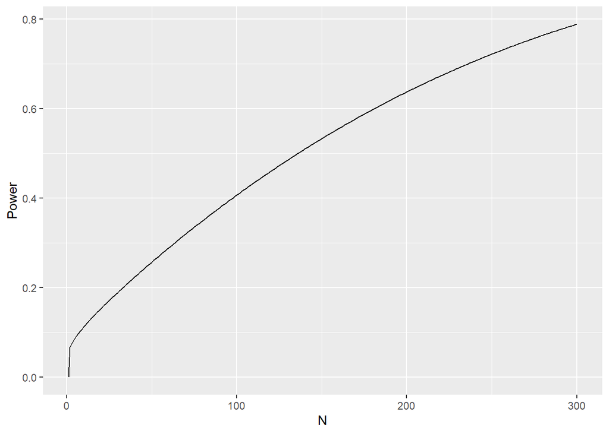

```r
## Question 4.b


## Don't forget to store the resulting dataframe as variable power.df

# power.df = data.frame(
#   n = c(), power=c("")
#   )

# power.df$power

n = c()
power = c()

power_calc = function(n){
  power_var = power.t.test(
    n = n,
    delta = 0.01,
    sd = 0.05,
    # power = 0.9,  # Not Needed
    sig.level = 0.05,
    type = "two.sample",  # Not sure as to what should be here? two since it is an improvement being tested?
    alternative = "one.sided",
  )$power

  return(power_var)
}

for (i in 1:300){
  n[i] = i
  power[i] = power_calc(i)
}

power.df = data.frame(
  n, power
)

ggplot(data = power.df, aes(x = power.df$n, y = power.df$power)) +
  geom_line() +
  xlab('N') +
  ylab('Power')
```

### Q5: Putting it all together

**a.** Load the data from file *UPMSP_SA_full_results.rds* and use `head()` to inspect its first rows. Use `filter()` to keep only the rows for which `Algorithm == "Full"`, then `group_by(Instance)` and `summarise(Mean.MS = mean(Makespan))` to create data frame `q5.df.summ`, according to the instructions provided in the assignment brief.

```r
## Question 5.a


## Don't forget to store the resulting summarised dataframe as variable q5.df.summ

df.upm = readRDS("UPMSP_SA_full_results.rds")

head(df.upm)
```

```
##   Algorithm           Instance Makespan
## 1      Full I_100_25_S_1-124_1      131
## 2      Full I_100_25_S_1-124_1      135
## 3      Full I_100_25_S_1-124_1      116
## 4      Full I_100_25_S_1-124_1       99
## 5      Full I_100_25_S_1-124_1      120
## 6      Full I_100_25_S_1-124_1      111
```

```r
dim(df.upm)
```

```
## [1] 23271     3
```

```r
df.upm1 = df.upm %>%
  filter(Algorithm == "Full")

dim(df.upm1)
```

```
## [1] 1700    3
```

```r
q5.df.summ = df.upm1 %>%
  group_by(Instance) %>%
  summarise(
    Mean.MS = mean(Makespan)
  )

dim(q5.df.summ)  # 57 Rows as expected
```

```
## [1] 57  2
```

**b.** Write down the test hypotheses $H_0$ and $H_1$. Recall from the question description that we are interested in checking if method “Full” has a mean *Makespan* lower than 240s.

For the experiment in this question, the hypotheses are:

$$
$$\begin{cases}
H_0: \mu_{makespan} >= 240\\
H_1: \mu_{makespan} < 240
\end{cases}$$

**c.** Estimate the statistical power of the one-sample t-test to detect a (normalised) effect size of $d = 0.5$, with the test is run with significance level $\alpha = 0.05$ and a one-sided $H_1$. Store the power as variable `q5.t.power`.

```r
## Question 5.c


## Don't forget to store the resulting summarized data frame as variable q5.t.power

q5.t.power = power.t.test(
  n = 57,
  delta = 0.5,
  sd = 1,
  sig.level = 0.05,
  type = "one.sample",  # Not sure as to what should be here? two since it is an improvement being tested?
  alternative = "one.sided",  # one sided since we are chaking if mean is lower?
)$power

q5.t.power
```

```
## [1] 0.9814151
```

**d.** Use `ggplot2` to visually check the normality of the values of `Mean.MS` in `q5.df.summ`. Check the example qq-plots earlier in this lab for code references. Is the sample consistent with a normal distribution?

```r
## Question 5.d
```

[output not shown]

**e.** As a baseline, run a `t.test()` on the values of `q5.df.summ$Mean.MS` (with $\alpha = 0.05$, a one-sided lower $H_1$, and the appropriate value of $\mu_0$). Observe the p-value and estimated (one-sided) confidence interval (note that one-sided CIs are open intervals). Store the p-value as variable `q5.parametric.p`.

```r
## Question 5.e


## Don't forget to store the resulting p-value as variable q5.parametric.p
```

[output not shown]

**f.** Now adapt the example code provided earlier and run a bootstrap t-test. Calculate the bootstrap p-value and store it as `q5.boot.p`. Compare it against the one provided by the parametric t-test in item **e**. (Tip: think about the directionality of $H_1$ and how it affects the calculation of $p$ in the bootstrap case.)

```r
set.seed(MY_STUDENT_ID)
## Question 5.f

## Don't forget to store the resulting p-value as variable q5.boot.p
```

[output not shown]